# Fitting Continuous Models Sampling Distributions Chapters 7 & 8

## This week in tgs data science

VICTR Research Methods

## Where we are going

| Transformation | F Known Analytic | F Known Simulation | F Unknown Simulation (bootstrap) | F Unknown Kernel density | F Unknown Method of Moments | F Unknown MLE | F Unknown Bayes |
| --- | --- | --- | --- | --- | --- | --- | --- |
| None | N/A | N/A |  |  |  |  | Soon |
| Mean | Soon |  |  | Today | Today | Today | Soon |
| Median |  |  |  | Today | Today | Today | Soon |
| Variance | Soon |  |  | Today | Today | Today | Soon |
| Min |  |  |  | Today | Today | Today | Soon |
| Max |  |  |  | Today | Today | Today | Soon |

## For the past several lectures, we have asked the question

\[ \text{Suppose } X \sim F_X \text{ where } F_X \text{ is unknown.}\\ \text{How might one estimate } F_X \text{ from } \boldsymbol{X}_N ?\]

## For the past several lectures, we have asked the question

\[ \text{Suppose } X \sim F_X \text{ where } F_X \text{ is unknown.}\\ \text{How might one estimate } F_X \text{ from } \boldsymbol{X}_N ?\]

### What are the different approaches?

- ??
- ??
- ??
- ??

## For the past several lectures, we have asked the question

\[ \text{Suppose } X \sim F_X \text{ where } F_X \text{ is unknown.}\\ \text{How might one estimate } F_X \text{ from } \boldsymbol{X}_N ?\]

### What are the different approaches?

- ECDF, EPDF
- Kernel density estimation
- Method of moments
- MLE

## Examples of \(\hat{F}_X\)

```r
Hmisc::getHdata(nhgh)
alb <- nhgh %>% filter(!is.na(albumin)) %>% `[[`("albumin")
N_alb <- length(alb)
par(mfrow = c(1,2))
hist(alb, main = "EPDF", freq = FALSE)
den1 <- density(alb, adjust = 1.5)
lines(den1, lwd = 3, col = "blue")

ecdfstar <- function(t, data, smooth){
  outer(t, data, function(a,b){ pnorm(a, b, smooth)}) %>% rowMeans
}
plot(ecdf(alb), main = "ECDF")
curve(ecdfstar(x, alb, den1$bw), add = TRUE, lwd = 3, col = "blue")
```

## Examples of \(\hat{F}_X\)

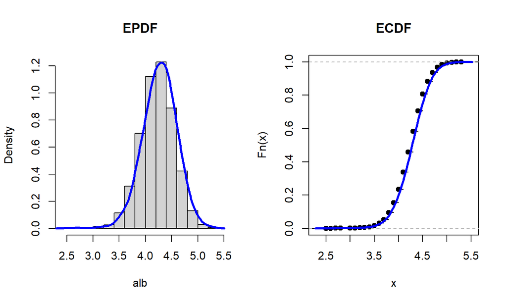

## Examples of \(\hat{F}_X\)

```r
mean_alb <- mean(alb)
var_alb <- var(alb)
scale_hat <- var_alb/mean_alb
shape_hat <- mean_alb^2/var_alb

par(mfrow = c(1,2))
hist(alb, main = "EPDF", freq = FALSE)
curve(dgamma(x, shape = shape_hat, scale = scale_hat), add = TRUE, lwd = 3, col = "blue")

plot(ecdf(alb), main = "ECDF")
curve(pgamma(x, shape = shape_hat, scale = scale_hat), add = TRUE, lwd = 3, col = "blue")
```

## Examples of \(\hat{F}_X\)

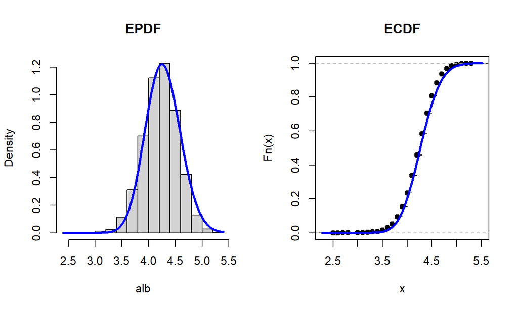

## Examples of \(\hat{F}_X\)

```r
nll <- function(shape, scale){
 fs <- dgamma(alb, shape = shape, scale = scale, log = TRUE)
 -sum(fs)
}
m1 <- stats4::mle(
    nll
  , method = "L-BFGS-B"
  , lower = c(0,0)
  , start = list(shape = shape_hat, scale = scale_hat)
)

par(mfrow = c(1,2))
hist(alb, main = "EPDF", freq = FALSE)
curve(dgamma(x, shape = m1@coef[1], scale = m1@coef[2]), add = TRUE, lwd = 3, col = "blue")

plot(ecdf(alb), main = "ECDF")
curve(pgamma(x, shape = m1@coef[1], scale = m1@coef[2]), add = TRUE, lwd = 3, col = "blue")
```

## Examples of \(\hat{F}_X\)

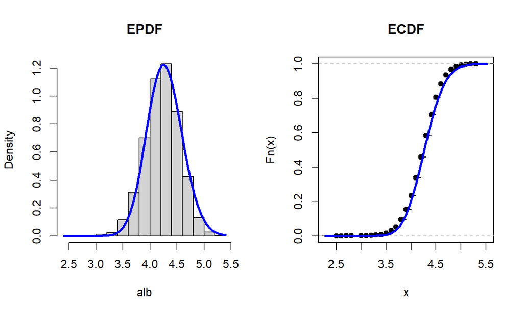

## A note about MLE

> In this class, we have presented a general purpose strategy for estimating \(\hat{F}_X\) via MLE. For specific models, there may exist specific methods or algorithms.

### For example

- For the normal model, the MLE solution is

\[\hat{\mu} = \bar{X};\ \ \widehat{\sigma^2} = \frac{N-1}{N}s^2\approx s^2\]

(For large \(N\), the \(\frac{N-1}{N}\) term is often omitted.)

## For the past several lectures, we have discussed how to sample from \(\hat{F}_X\)

| Method | Strategy |
| --- | --- |
| MM | `r` function |
| MLE | `r` function |
| KDE | `runif` + `q` function |
| ECDF | Bootstrap |

> **Why sample from \(\hat{F}_X\)?**

## For the past several lectures, we have discussed how to sample from \(\hat{F}_X\)

| Method | Strategy |
| --- | --- |
| MM | `r` function |
| MLE | `r` function |
| KDE | `runif` + `q` function |
| ECDF | Bootstrap |

> **Why sample from \(\hat{F}_X\)?** Because if we can sample, than we can use simulation to generate the sampling distribution.

## Examples of Sampling from \(\hat{F}_X\)

```r
# Kernel density estimation
epdfstar <- function(t, data, smooth){
  outer(t, data, function(a,b){ dnorm(a, b, smooth)}) %>% rowMeans
}
# Approximate q function with lookup table from KDE estimate
tbl <- data.frame(
    x = seq(0,10,by = 0.01)
)
tbl$p <- ecdfstar(tbl$x, alb, den1$bw)
tbl <- tbl[!duplicated(tbl$p),]

qalb <- function(ps, tbl){
  rows <- cut(ps, tbl$p, labels = FALSE)
  tbl[rows, "x"]
}

U <- runif(100)
Y <- qalb(U, tbl)
```

## Examples of sampling from \(\hat{F}_X\)

```r
# Kernel density estimation (Continued)
par(mfrow = c(1,2))
plot(ecdf(alb), main = "ECDF")
plot(ecdf(Y), add = TRUE, col = "blue")
ps <- ppoints(50)
sample1 <- quantile(alb, ps)
sample2 <- quantile(Y, ps)
plot(sample1, sample2, xlab = "Observed data", ylab = "Sampled data", main = "Two sample QQ plot")
abline(0,1)
```

## Examples of sampling from \(\hat{F}_X\)

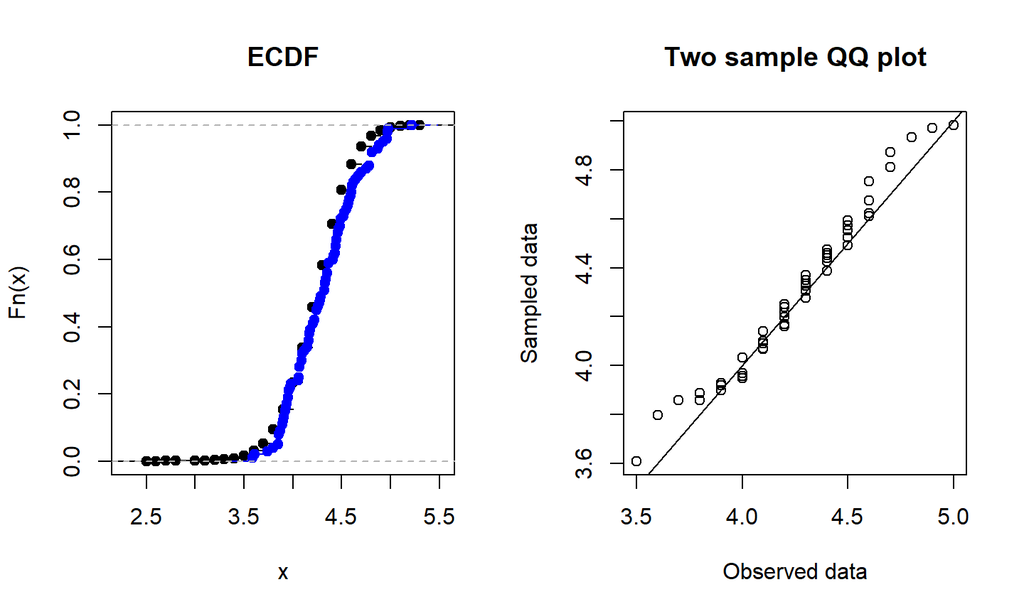

## Examples of sampling from \(\hat{F}_X\)

```r
# Method of moments
Y <- rgamma(100, shape = shape_hat, scale = scale_hat)

par(mfrow = c(1,2))
plot(ecdf(alb), main = "ECDF")
plot(ecdf(Y), add = TRUE, col = "blue")
ps <- ppoints(50)
sample1 <- quantile(alb, ps)
sample2 <- quantile(Y, ps)
plot(sample1, sample2, xlab = "Observed data", ylab = "Sampled data", main = "Two sample QQ plot")
abline(0,1)
```

## Examples of sampling from \(\hat{F}_X\)

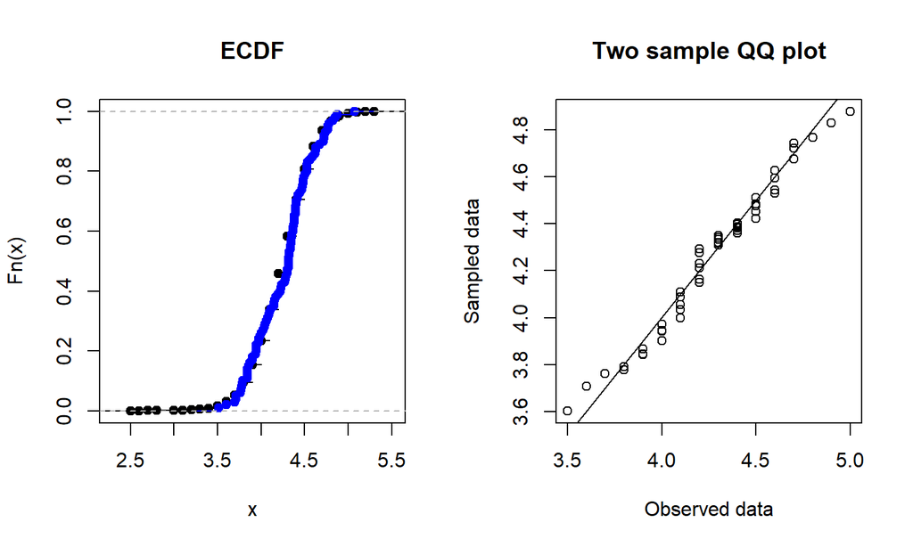

## Examples of sampling from \(\hat{F}_X\)

```r
# MLE
Y <- rgamma(100, shape = m1@coef[1], scale = m1@coef[2])

par(mfrow = c(1,2))
plot(ecdf(alb), main = "ECDF")
plot(ecdf(Y), add = TRUE, col = "blue")
ps <- ppoints(50)
sample1 <- quantile(alb, ps)
sample2 <- quantile(Y, ps)
plot(sample1, sample2, xlab = "Observed data", ylab = "Sampled data", main = "Two sample QQ plot")
abline(0,1)
```

## Examples of sampling from \(\hat{F}_X\)

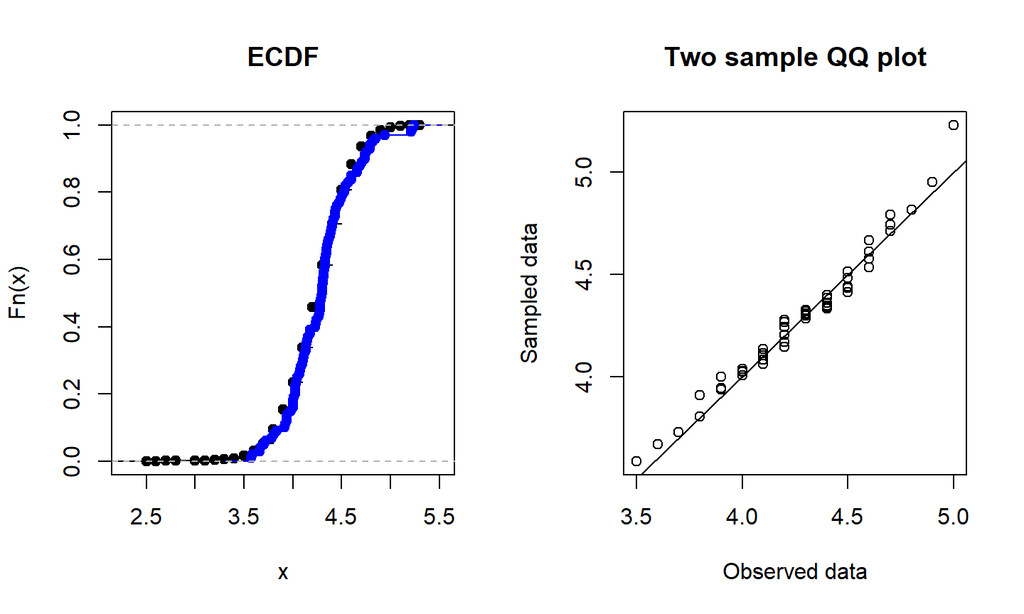

## Examples of sampling from \(\hat{F}_X\)

```r
# Sample function
Y <- sample(alb, 100, replace = TRUE)

par(mfrow = c(1,2))
plot(ecdf(alb), main = "ECDF")
plot(ecdf(Y), add = TRUE, col = "blue")
ps <- ppoints(50)
sample1 <- quantile(alb, ps)
sample2 <- quantile(Y, ps)
plot(sample1, sample2, xlab = "Observed data", ylab = "Sampled data", main = "Two sample QQ plot")
abline(0,1)
```

## Examples of sampling from \(\hat{F}_X\)

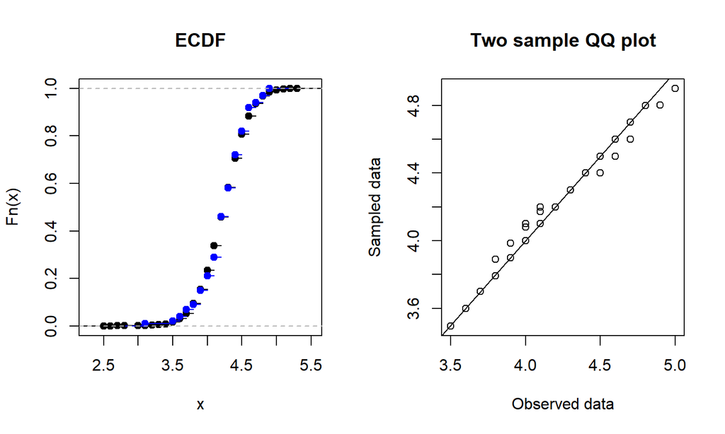

## Strategies for sampling from \(\hat{F}_X\)

| Method | Strategy |
| --- | --- |
| MM | `r` function |
| MLE | `r` function |
| KDE | `runif` + `q` function |
| ECDF | Bootstrap |

> **Why sample from \(\hat{F}_X\)?** Because if we can sample, than we can use simulation to generate the sampling distribution.

> **Why do we care about the sampling distribution?**

## Strategies for sampling from \(\hat{F}_X\)

| Method | Strategy |
| --- | --- |
| MM | `r` function |
| MLE | `r` function |
| KDE | `runif` + `q` function |
| ECDF | Bootstrap |

> **Why sample from \(\hat{F}_X\)?** Because if we can sample, than we can use simulation to generate the sampling distribution.

> **Why do we care about the sampling distribution?** The variation of the sampling distribution is the uncertainty associated with a summary measure calculated from the sample, \(\boldsymbol{X}_N\).

## Where we are going

| Transformation | F Known Analytic | F Known Simulation | F Unknown Simulation (bootstrap) | F Unknown Kernel density | F Unknown Method of Moments | F Unknown MLE | F Unknown Bayes |
| --- | --- | --- | --- | --- | --- | --- | --- |
| None | N/A | N/A |  |  |  |  | Soon |
| Mean | Soon |  |  | Today | Today | Today | Soon |
| Median |  |  |  | Today | Today | Today | Soon |
| Variance | Soon |  | Review | Today | Today | Today | Soon |
| Min |  |  |  | Today | Today | Today | Soon |
| Max |  |  |  | Today | Today | Today | Soon |

## Refresher on the bootstrap

[figure not shown]

## Refresher on the bootstrap

In this example we are going to calculate the sampling distribution of the sample variance.

[figure not shown]

## Refresher

```r
M <- 5000
out <- rep(NA, M)
for(i in 1:M){
  out[i] <- sample(alb, N_alb, replace = TRUE) %>% var
}

obs_var <- var(alb)
hist(out, freq = FALSE, main = "", xlab = "Sample variances")
abline(v = obs_var, col = "blue", lwd = 3)
```

## Refresher

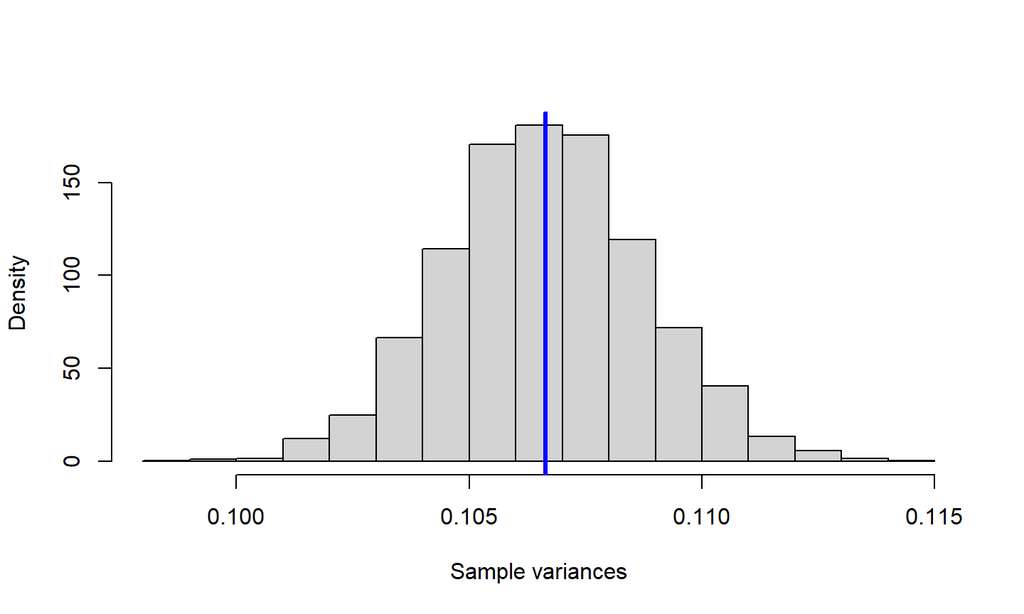

## Where we are going

| Transformation | F Known Analytic | F Known Simulation | F Unknown Simulation (bootstrap) | F Unknown Kernel density | F Unknown Method of Moments | F Unknown MLE | F Unknown Bayes |
| --- | --- | --- | --- | --- | --- | --- | --- |
| None | N/A | N/A |  |  |  |  | Soon |
| Mean | Soon |  |  | Today | Today | Today | Soon |
| Median |  |  |  | Today | Today | Today | Soon |
| Variance | Soon |  | Reviewed | Today | Now | Today | Soon |
| Min |  |  |  | Today | Today | Today | Soon |
| Max |  |  |  | Today | Today | Today | Soon |

## Sampling distribution of the variance

### By simulation

```r
R <- 5000
out <- rep(NA, R)
for(i in 1:R){
  b <- rgamma(N_alb, shape = shape_hat, scale = scale_hat)
  out[i] <- var(b)
}

obs_var <- var(alb)
hist(out, freq = FALSE, main = "", xlab = "Sample variances")
abline(v = obs_var, col = "blue", lwd = 3)
```

## Sampling distribution of the variance

### By simulation

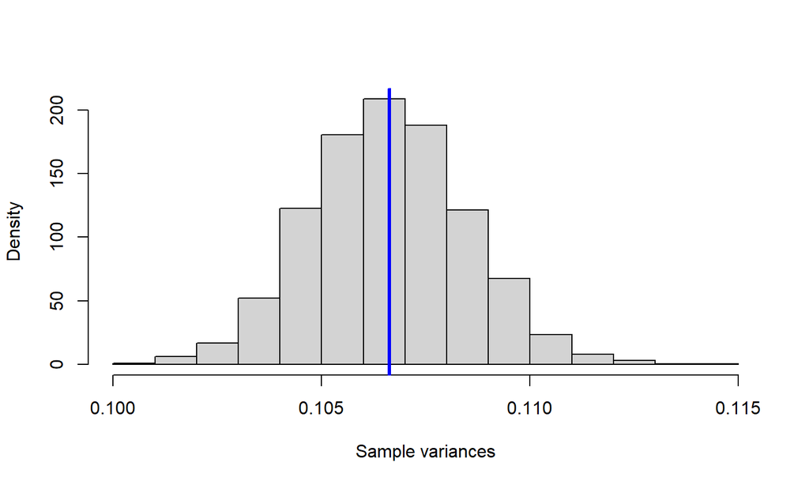

## Sampling distribution of the variance

### Compare bootstrap and simulation

```r
# BOOTSTRAP
M <- 5000
out <- rep(NA, M)
for(i in 1:M){
  out[i] <- sample(alb, N_alb, replace = TRUE) %>% var
}

# SIMULATION FROM Fhat (estimated with MM)
R <- 5000
out <- rep(NA, R)
for(i in 1:R){
  out[i] <- rgamma(N_alb, shape = shape_hat, scale = scale_hat) %>% var
}
```

## Sampling distribution of the variance

### Compare bootstrap and simulation

- Note the similarities.
- Recall that the ECDF is an estimate of \(F_X\).
- The **bootstrap** is sampling from the **ECDF estimate** of \(F_X\).
- The second simulation is sampling from the **method of moments** estimate of \(F_X\).

## Useful Notation (For this class only)

| Notation | Meaning |
| --- | --- |
| \(\hat{F}_X^{\text{b}}\) | The ECDF estimate of \(F_X\) |
| \(\hat{F}_X^{\text{mm}}\) | The method of moments estimate of \(F_X\) |
| \(\hat{F}_X^{\text{mle}}\) | The maximum likelihood estimate of \(F_X\) |
| \(\hat{F}_X^{\text{kde}}\) | The kernel density estimate of \(F_X\) |

## The big picture

[figure not shown]

## Sampling distribution of the variance

> The procedure used to generate the sampling distribution of the variance with \(\hat{F}_X^{\text{mm}}\) or \(\hat{F}_X^{\text{b}}\) could also have used \(\hat{F}_X^{\text{mle}}\) or \(\hat{F}_X^{\text{kde}}\).

## Sampling distribution of the variance and other summary measures

> The procedure used to generate the sampling distribution of the variance with \(\hat{F}_X^{\text{mm}}\) or \(\hat{F}_X^{\text{b}}\) could also have used \(\hat{F}_X^{\text{mle}}\) or \(\hat{F}_X^{\text{kde}}\).

> The procedure used to generate the sampling distribution of the variance could also be applied generating the sampling distribution of the mean, median, min, and max.

## Hands-on

Using the NHANES data, generate the sampling distribution for the mean of serum creatinine using a MLE estimate of the gamma distribution.

```r
scr <- nhgh$SCr[!is.na(nhgh$SCr)]
nll <- function(shape, scale){
  fs <- dgamma(
    scr
    , shape = shape
    , scale = scale
    , log = TRUE
  )
  -sum(fs)
}
```

## Hands-on

```r
# (Continued)
# Start at MM solution
start_scale <- var(scr)/mean(scr)
start_shape <- mean(scr)^2/var(scr)
stats4::mle(
    nll
  , method = "L-BFGS-B"
  , lower = c(0.01,0.01)
  , start = list(shape = start_shape, scale = start_scale)
)
```

## Hands-on

Using the NHANES data, generate the sampling distribution for the inter-quartile range (IQR) of serum creatinine using a MLE estimate of the gamma distribution.

## All done

| Transformation | F Known Analytic | F Known Simulation | F Unknown Simulation (bootstrap) | F Unknown Kernel density | F Unknown Method of Moments | F Unknown MLE | F Unknown Bayes |
| --- | --- | --- | --- | --- | --- | --- | --- |
| None | N/A | N/A |  |  |  |  | Soon |
| Mean | Soon |  |  |  |  |  | Soon |
| Median |  |  |  |  |  |  | Soon |
| Variance | Soon |  |  |  |  |  | Soon |
| Min |  |  |  |  |  |  | Soon |
| Max |  |  |  |  |  |  | Soon |

## But wait! There’s more!

## Examples

```r
# Sampling distribution of the MIN with KDE estimate of F
R <- 5000
out <- rep(NA, M)
for(i in 1:R){
  out[i] <- runif(N_alb) %>% qalb(tbl) %>% min
}
hist(out, main = "", freq = FALSE, xlab = "Sample mins")
abline(v = min(alb), lwd = 3, col = "blue")
```

## Examples

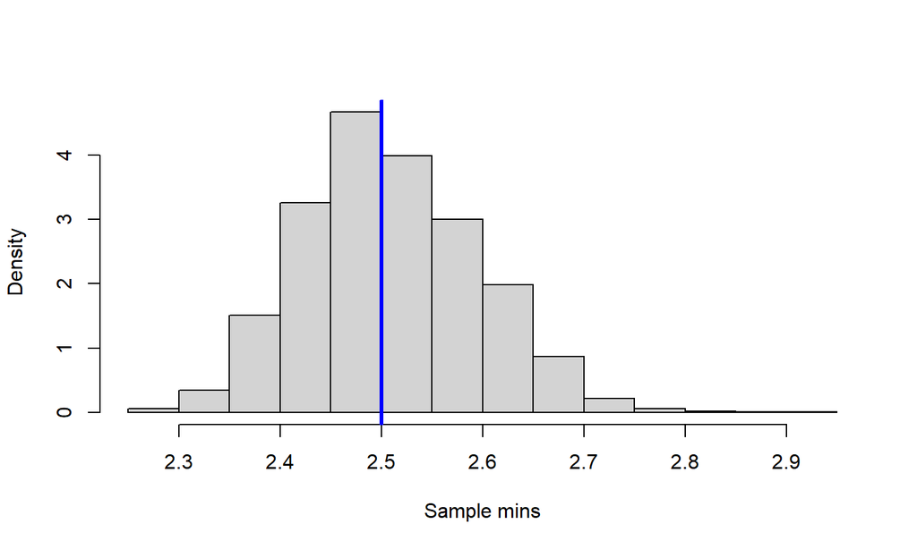

## A trick to speed-up simulation

> **Setting:** Generating the sampling distribution of a quantile related summary measure (min, median, max, etc.)

Rather than simulating \(N \text{ (Sample size)} \times R \text{ (replicates)}\) draws of the data, we can take advantage of the properties of order statistics and only simulate \(R\) draws.

## A trick to speed-up simulation

> **Setting:** Generating sampling distribution of a quantile related summary measure (min, median, max, etc.)

> **The trick:** \[\text{If } U \sim \text{uniform}(0,1),\text{ then }U_{(k)} \sim \text{beta}(k, N-k+1)\] **In words:** The order statistics distribution for uniform data is the beta distribution.

## A trick to speed-up simulation

> **Setting:** Generating sampling distribution of a quantile related summary measure (min, median, max, etc.)

> **The trick:** \[\text{If } U \sim \text{uniform}(0,1),\text{ then }U_{(k)} \sim \text{beta}(k, N-k+1)\] **In words:** The order statistics distribution for uniform data is the beta distribution.

> **Implementation in R:**

```r
# Sampling distribution of the MIN with KDE estimate of F
out2 <- rbeta(5000, 1, N_alb) %>% qalb(tbl)
```

## Compare sampling distributions of the min from both approaches

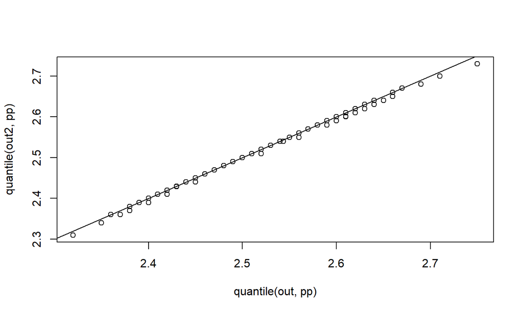

```r
pp <- ppoints(100)
plot(quantile(out, pp), quantile(out2, pp)); abline(0,1)
```

## U + Q and B + Q

When estimating sampling distributions of summary measures of order statistics, the B + Q approach is a computational short cut.

## But wait! There’s even more!

## There is some uncertainty that this procedure fails to capture

[figure not shown]

## There is some uncertainty that this procedure fails to capture

> We estimated \(\hat{F}_X\) from data. However, the procedure treats \(\hat{F}_X\) **as if it were known**!

## There is some uncertainty that this procedure fails to capture

> We estimated \(\hat{F}_X\) from data. However, the procedure treats \(\hat{F}_X\) **as if it were known**!

> Will our estimate of \(\hat{F}_X\) change from dataset to dataset? **Yes!**

## There is some uncertainty that this procedure fails to capture

> We estimated \(\hat{F}_X\) from data. However, the procedure treats \(\hat{F}_X\) **as if it were known**!

> Will our estimate of \(\hat{F}_X\) change from dataset to dataset? **Yes!**

> How might we capture the uncertainty from estimating \(\hat{F}_X\)?

## One option to capture the uncertainty

[figure not shown]

## Example with Method of Moments

```r
# Estimation outside loop
R <- 5000
out1 <- rep(NA, R)
scale_hat <- var(alb)/mean(alb)
shape_hat <- mean(alb)^2/var(alb)
for(i in 1:R){
  out1[i] <- rgamma(N_alb, shape = shape_hat, scale = scale_hat) %>% var
}

# Estimation inside loop
out2 <- rep(NA, R)
for(i in 1:R){
  boot_alb <- sample(alb, N_alb, replace = TRUE)
  scale_hat <- var(boot_alb)/mean(boot_alb)
  shape_hat <- mean(boot_alb)^2/var(boot_alb)
  out2[i] <- rgamma(N_alb, shape = shape_hat, scale = scale_hat) %>% var
}

boxplot(list(`Estimation outside loop` = out1, `Estimation inside loop` = out2))
```

## Example with Method of Moments

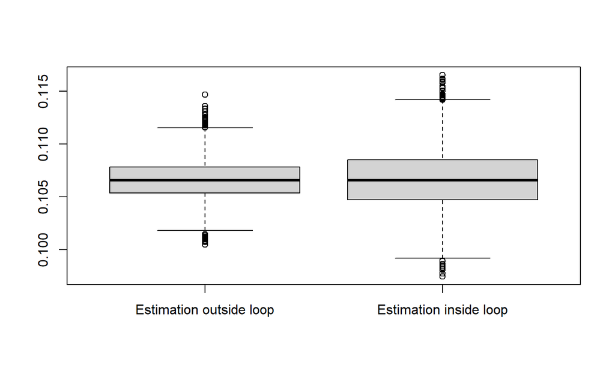

## Example with Method of Moments

- Which approach generates a wider sampling distribution?
- What is the source of the the extra uncertainty?

## Big picture

[figure not shown]

## Middle 95% of the sampling distribution

The interval corresponding to the middle 95% of the sampling distribution is called the **95% Confidence Interval**. It will play an important role when we discuss inference formally.

## Middle 95% of the sampling distribution

The middle 95% of a distribution is not a precisely defined term.

> **Option 1:** The interval that results by calculating the 0.025 and 0.975 quantiles. (This is sometimes called the **symmetric density interval**.)

> **Option 2:** The shortest interval that contains 95% of the density. (This is called the **highest density interval**.)

## Middle 95% of the sampling distribution

> If the distribution is symmetric, then the **symmetric density interval** will be the same as the **highest density interval**.

> The **highest density interval** is helpful if the distribution is not symmetric.

## SDI vs HDI

```r
Y <- rexp(1000)
sdi <- quantile(Y, c(0.025, 0.975))
hdi <- HDInterval::hdi(Y)

par(mfrow = c(2,1), mar = rep(0,4), oma = rep(2,4))
hist(Y, xlim = range(Y), main = "", axes = FALSE, breaks = 50)
abline(v = sdi, col = "blue", lwd = 3)
abline(v = hdi, col = 'red', lwd = 3)
legend("topright", c("HDI", "SDI"), col = c("red","blue"), lwd = 3, bty = "n")
boxplot(Y, horizontal = TRUE, axes = FALSE)
abline(v = sdi, col = "blue", lwd = 3)
abline(v = hdi, col = 'red', lwd = 3)
title(xlab = "Exponential(1) draws", outer = TRUE, line = .5)
```

## SDI vs HDI

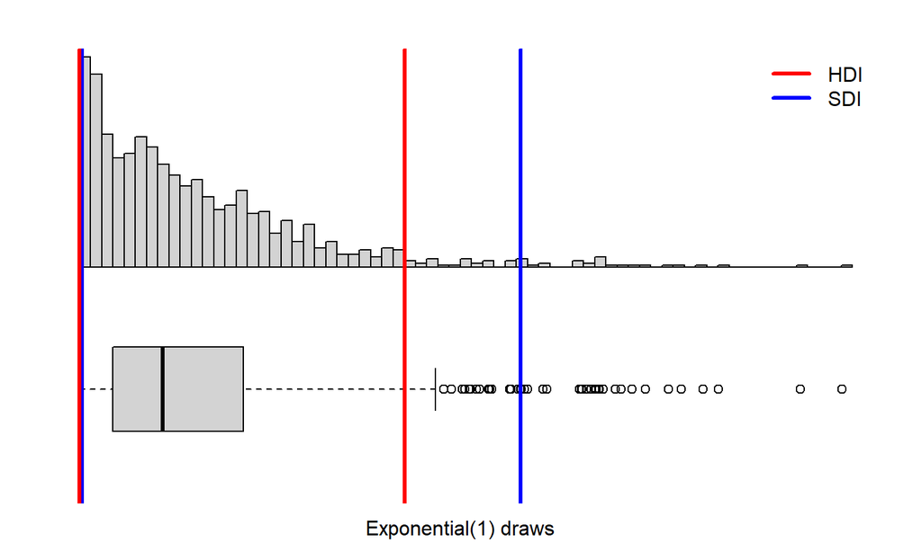